# STR Explorer - create your own workflow for personalized medical research with STRs.

Oxana (Sachenkova) Lundström<sup>1</sup> (oxana.lundstrom@dbb.su.se, @merenlin), Max Verbiest<sup>2</sup>, Maria Anisimova<sup>2</sup>

1. Stockholm University, Sweden

2. Institute of Applied Simulations, ZHAW Wädenswil

# Pipeline to systematically search for **short tandem repeat (STR) biomarkers** in different medical conditions.

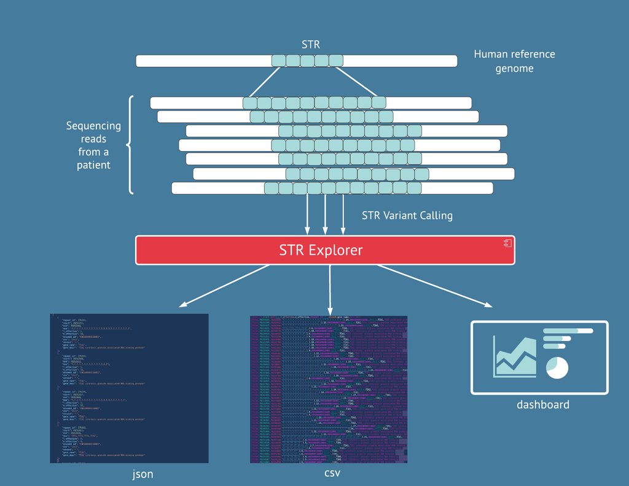

### Fork the project on github to customize the workflow or use the current version at **str-explorer.herokuapp.com**.

# Why?

Microsatellite sequences are short tandem repeats(STRs) of two to six nucleotides. They are known to be hypervariable due to the accumulation of length mutations by intra-allelic polymerase slippage on microsatellite sequence during replication.

Current evidence suggests that STRs play an important role in cancer and other diseases. In colorectal cancer(CRC) variation in STR regions have been shown to influence protein-expression levels and increase tumor progression. The instability of microsatellite regions (**MSI marker**) is used by clinicians today to classify CRC tumors into different groups(Guinney (2015)). This marker includes only five microsatellite regions and doesn’t exploit the whole variety of this phenomena.

Currently it is unknown whether distinct cancer groups exhibit distinct patterns of STR variation and in what CRC-related functional pathways STRs are involved.

# What?

STRs have been poorly studied until very recently due to their highly polymorphic nature which complicates their annotation. Moreover, genotyping and analyzing STR variants involves large amounts of data and working with many different biological data formats. We have developed a pipeline to systematically search for STR biomarkers in **colorectal cancer** that can be easily adapted for similar studies in other medical conditions. Our pipeline is the first building block towards a workflow for **personalized medicine** approach through STRs.

[figure not shown]

# How?

## STR genotyping workflow

The statistical framework **TRAL** (Schaper (2015)) have been used to find STRs in human reference genome. These inferred STRs have been further genotyped using **GangSTR** (Mousavi (2019)) on more than 400 genomes from patients with colorectal cancer available to us through the TCGA (Cancer Genome Atlas 2012). Our pipeline then filters genotyped calls on sequencing quality, read coverage and ML estimate of GangSTR and transforms the vcf call files into records in our relational database.

[figure not shown]

## REST API

The results are presented as a relational database with programmatic access through a REST-full API, - STR Explorer. Additional Python modules are available to add more genotyped data to the database. Future plans include creating of an interactive dashboard to visualize and analyse results.

[figure not shown]

# References

Cancer Genome Atlas, N. 2012. “Comprehensive Molecular Characterization of Human Colon and Rectal Cancer.” *Nature*, no. 487: 330–37. https://doi.org/10.1038/nature11252.

Guinney. 2015. “Deep Learning Based Tissue Analysis Predicts Outcome in Colorectal Cancer.” *Nature Medicine* 21: no. 1350. https://doi.org/10.1038/nm.3967.

Mousavi, Nima. 2019. “Profiling the Genome-Wide Landscape of Tandem Repeat Expansions.” *Nucleic Acids Research* 47: e90. https://doi.org/10.1093/nar/gkz501.

Schaper, Elke. 2015. “TRAL, Tandem Repeat Annotation Library.” *Bioinformatics*, no. 18: 3051–53. https://doi.org/10.1093/bioinformatics/btv306.